# [ST790-003 HW6](http://hua-zhou.github.io/teaching/st790-2015spr/ST790-2015-HW6.pdf) Solution Sketch

Display system information.

```julia
versioninfo()
```

```
Julia Version 0.3.7
Commit cb9bcae (2015-03-23 21:36 UTC)
Platform Info:
  System: Darwin (x86_64-apple-darwin13.4.0)
  CPU: Intel(R) Core(TM) i7-3720QM CPU @ 2.60GHz
  WORD_SIZE: 64
  BLAS: libopenblas (USE64BITINT DYNAMIC_ARCH NO_AFFINITY Sandybridge)
  LAPACK: libopenblas
  LIBM: libopenlibm
  LLVM: libLLVM-3.3
```

Load the `Convex.jl` and `JuMP.jl` packages.

```julia
using Convex, JuMP
```

## Q1. Optimal design.

Create candidate design points, using dummy coding for factors.

```julia
I = 3; J = 4
C = zeros(I * J, I - 1 + J)
row = 1
dummyI = zeros(1, I - 1)
dummyJ = zeros(1, J - 1)
for i = 1:I
    for j = 1:J
        # Intercept
        C[row, 1] = 1.0
        # Dummy coding for factor 1
        fill!(dummyI, 0.0)
        if i > 1
            dummyI[i - 1] = 1.0
        end
        C[row, 2:I] = dummyI
        # Dummy coding for factor 2
        fill!(dummyJ, 0.0)
        if j > 1
            dummyJ[j - 1] = 1.0
        end
        C[row, I+1:end] = dummyJ
        # Increase row index
        row += 1
    end
end
```

Delete the last level combination.

```julia
C = C[1:end-1, :]
```

```
11x6 Array{Float64,2}:
 1.0  0.0  0.0  0.0  0.0  0.0
 1.0  0.0  0.0  1.0  0.0  0.0
 1.0  0.0  0.0  0.0  1.0  0.0
 1.0  0.0  0.0  0.0  0.0  1.0
 1.0  1.0  0.0  0.0  0.0  0.0
 1.0  1.0  0.0  1.0  0.0  0.0
 1.0  1.0  0.0  0.0  1.0  0.0
 1.0  1.0  0.0  0.0  0.0  1.0
 1.0  0.0  1.0  0.0  0.0  0.0
 1.0  0.0  1.0  1.0  0.0  0.0
 1.0  0.0  1.0  0.0  1.0  0.0
```

Compute optimal D design.

```julia
include("hw6.jl")
# Use SCS solver for SDP
using SCS
solver = SCSSolver(verbose=0)
set_default_solver(solver)

using Gadfly

@time prob = optimdesign(C; design='D')

probmat = reshape([prob, 0.0], J, I)'
display(probmat)
rowidx, colidx = ind2sub(size(probmat), 1:length(probmat))
plot(x=colidx, y=rowidx, color=flipdim(probmat, 1), Geom.rectbin,
    Guide.XLabel("Factor B"), Guide.YLabel("Factor A"),
    Scale.x_discrete, Scale.y_discrete, Guide.title("D-optimal Design"),
    Scale.ContinuousColorScale(Scale.lab_gradient(color("white"), color("black"))))
```

```
elapsed time:
```

```
3x4 Array{Float64,2}:
 0.0819149  0.0819701  0.0819711  0.108918
 0.0819208  0.0819677  0.0819696  0.108898
 0.0968219  0.0968216  0.0968226  0.0
```

```
0.119107148 seconds (5332752 bytes allocated)
```

[figure not shown]

Compute optimal E design.

```julia
include("hw6.jl")
@time prob = optimdesign(C; design='E')
display("optimal value:")
display(1.0 / eigmin(C' * diagm(prob[:, 1]) * C))

probmat = reshape([prob, 0.0], J, I)'
display(probmat)
rowidx, colidx = ind2sub(size(probmat), 1:length(probmat))
plot(x=colidx, y=rowidx, color=flipdim(probmat, 1), Geom.rectbin,
    Guide.XLabel("Factor B"), Guide.YLabel("Factor A"),
    Scale.x_discrete, Scale.y_discrete, Guide.title("E-optimal Design"),
    Scale.ContinuousColorScale(Scale.lab_gradient(color("white"), color("black"))))
```

```
elapsed time:
```

```
"optimal value:"
```

```
13.000006527970886
```

```
3x4 Array{Float64,2}:
 0.439126   0.115957   0.115957   0.130013
 0.0496919  0.0129425  0.0129425  0.0237687
 0.0498191  0.0248913  0.0248913  0.0
```

```
0.065160238 seconds (1154216 bytes allocated)
```

[figure not shown]

Compute opitmal A design. Somehow it yields a solution inferior to that from Matlab. I'm not sure why???

```julia
include("hw6.jl")
@time prob = optimdesign(C; design='A')
display("optimal value:")
display(trace(inv(C' * diagm(prob[:, 1]) * C)))

probmat = reshape([prob, 0.0], J, I)'
display(probmat)

rowidx, colidx = ind2sub(size(probmat), 1:length(probmat))
plot(x=colidx, y=rowidx, color=flipdim(probmat, 1), Geom.rectbin,
    Guide.XLabel("Factor B"), Guide.YLabel("Factor A"),
    Scale.x_discrete, Scale.y_discrete, Guide.title("A-optimal Design"),
    Scale.ContinuousColorScale(Scale.lab_gradient(color("white"), color("black"))))
```

```
elapsed time:
```

```
"optimal value:"
```

```
38.92577769242943
```

```
3x4 Array{Float64,2}:
 0.199831  0.0863714  0.0863714  0.105559
 0.100547  0.0508963  0.0508963  0.0798883
 0.104162  0.0677262  0.0677262  0.0
```

```
0.09812649 seconds (1746904 bytes allocated)
```

[figure not shown]

## Q3. Best subset regression on the prostate cancer data

Read in the prostate cancer data.

```julia
prostate = readdlm("prostate.txt", '\t'; header=true)
X = float64(prostate[1][:, 2:9])
y = float64(prostate[1][:, 10])
trainidx = (prostate[1][:, 11] .== "T");
```

Standardize predictors and add intercept.

```julia
X = X .- mean(X, 1)
X = X ./ std(X, 1)
X = [ones(size(X, 1), 1) X];
```

Train/test split.

```julia
Xtr = X[trainidx, :]
ytr = y[trainidx]
Xte = X[~trainidx, :]
yte = y[~trainidx];
```

Solve a sequence of best subset regressions. The function `lsqbestsubset` is implemented via the `JuMP.jl` package because of its capability to incoporate SOS1 constraints.

```julia
include("hw6.jl")
# Use Gurobi solver becoz it accepts SOS constraints
using Gurobi
solver = GurobiSolver(OutputFlag=1)
set_default_solver(solver)

klist = 0:8
βhat_path = zeros(size(Xtr, 2), length(klist))
err_path = zeros(1, length(klist))
aic_path = zeros(1, length(klist))
bic_path = zeros(1, length(klist))
n = length(ytr)
@time for i = 1:length(klist)
    βhat_path[:, i] = lsqbestsubset(ytr, Xtr, klist[i])
    err_path[i] = norm(yte - Xte * βhat_path[:, i])^2 / length(yte)
    aic_path[i] = 2.0n * log(norm(ytr - Xtr * βhat_path[:, i])) +
        2.0 * (log(2.0π) + 1.0) + 2.0 * countnz(βhat_path[:, i])
    bic_path[i] = 2.0n * log(norm(ytr - Xtr * βhat_path[:, i])) +
        2.0 * (log(2.0π) + 1.0) + log(n) * countnz(βhat_path[:, i])
end
```

```
elapsed time: 0.246431481 seconds (2726180 bytes allocated)
```

Plot solution path.

```julia
using DataFrames, Gadfly

p = size(X, 2) - 1
bspath = DataFrame(Predictor = rep(["lcavol","lweight","age","lbph",
    "svi","lcp","gleason","pgg45"], length(klist)),
    Coeff = reshape(βhat_path[2:end, :], (p * length(klist))),
    k = rep(klist, each=p))

plot(bspath, x=:k, y=:Coeff, color=:Predictor, Geom.line,
    Guide.XLabel("model size"), Guide.YLabel("βhat"),
    Guide.Title("Best subset regression"),
    Scale.x_continuous(minvalue=0, maxvalue=8),
    Scale.color_discrete_hue)
```

[figure not shown]

Plot test errors.

```julia
plot(x = klist, y = err_path, Geom.point, Geom.line,
Guide.XLabel("model size"), Guide.YLabel("test error"),
    Scale.x_continuous(minvalue=0, maxvalue=8),
    Guide.Title("Best subset regression"))
```

[figure not shown]

Plot AIC trace plot.

```julia
plot(x = klist, y = aic_path, Geom.point, Geom.line,
    Guide.XLabel("model size"), Guide.YLabel("AIC"),
    Scale.x_continuous(minvalue=0, maxvalue=8),
    Guide.Title("Best subset regression"))
```

[figure not shown]

Plot BIC trace plot.

```julia
plot(x = klist, y = bic_path, Geom.point, Geom.line,
    Guide.XLabel("model size"), Guide.YLabel("BIC"),
    Scale.x_continuous(minvalue=0, maxvalue=8),
    Guide.Title("Best subset regression"))
```

[figure not shown]

## Q2. Complete Lena

Load the $128 \times 128$ Lena picture with missing pixels.

```
Gray Image with:
  data: 128x128 Array{Gray{UfixedBase{Uint8,8}},2}
  properties:
    imagedescription: <suppressed>
    spatialorder:  x y
    pixelspacing:  1 1
```

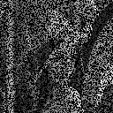

```julia
using Images

lena = Images.imread("lena128missing.png")
show(lena)
Y = reinterpret(Float64, data(float64(lena)))
grayim(lena)
```

"Complete" Lena by minimizing nuclear norm.

```
elapsed time: 199.824201744 seconds (71803534752 bytes allocated, 49.18% gc time)
```

[figure not shown]

```julia
include("hw6.jl")
# Use SCS solver for SDP
using SCS
solver = SCSSolver(verbose=0)
set_default_solver(solver)

## Use Mosek solver
#using Mosek
#solver = MosekSolver(LOG=1)
#set_default_solver(solver)

@time lena_complete = matcomp(Y)
grayim(lena_complete)
```

## Q4. Ranking MLB teams

Read in the 2014 season American League win-loss data at http://espn.go.com/mlb/standings/grid/_/year/2014

```julia
AL14 = readdlm("ymat.csv", ','; header=true)
team = AL14[2]
display(team)
AL14 = AL14[1]
```

```
1x15 Array{String,2}:
 "BAL"  "BOS"  "CHW"  "CLE"  "DET"  …  "OAK"  "SEA"  "TB"  "TEX"  "TOR"
```

```
15x15 Array{Float64,2}:
 0.0  11.0   5.0   3.0   1.0   4.0  …  13.0   2.0   5.0  12.0   6.0  11.0
 8.0   0.0   4.0   2.0   1.0   4.0      7.0   3.0   1.0   9.0   4.0   7.0
 1.0   3.0   0.0   9.0   9.0   3.0      2.0   4.0   3.0   5.0   2.0   5.0
 4.0   5.0  10.0   0.0   8.0   5.0      4.0   2.0   2.0   4.0   6.0   2.0
 5.0   5.0  10.0  11.0   0.0   4.0      3.0   5.0   2.0   3.0   4.0   1.0
 3.0   3.0   3.0   2.0   3.0   0.0  …   4.0   8.0   9.0   2.0  11.0   4.0
 4.0   1.0  13.0   9.0   6.0   3.0      4.0   5.0   2.0   4.0   5.0   4.0
 2.0   5.0   5.0   5.0   4.0  12.0      2.0  10.0   7.0   5.0  14.0   5.0
 3.0   2.0  10.0   8.0  10.0   3.0      3.0   1.0   5.0   2.0   2.0   4.0
 6.0  12.0   5.0   3.0   4.0   2.0      0.0   2.0   3.0   8.0   4.0  11.0
 4.0   4.0   3.0   4.0   2.0  11.0  …   4.0   0.0   9.0   4.0   9.0   4.0
 2.0   5.0   4.0   4.0   4.0  10.0      3.0  10.0   0.0   4.0   9.0   4.0
 7.0  10.0   2.0   2.0   4.0   5.0     11.0   2.0   3.0   0.0   5.0   8.0
 1.0   2.0   4.0   1.0   3.0   8.0      3.0  10.0  10.0   2.0   0.0   2.0
 8.0  12.0   2.0   4.0   5.0   3.0      8.0   3.0   3.0  11.0   4.0   0.0
```

Let's fit the Bradley-Terry model for ranking. Unfortunately `Convex.jl` does *not* model GP (geometric program). Therefore use its `logsumexp` function, which depends exponential cone programming e.g. implemented in solver SCS.

```julia
include("hw6.jl")
# Use SCS solver for SDP
using SCS
solver = SCSSolver(verbose=0)
set_default_solver(solver)

## Use Mosek solver
#using Mosek
#solver = MosekSolver(LOG=1)
#set_default_solver(solver)

## Use Gurobi solver
#using Gurobi
#solver = GurobiSolver(OutputFlag=1)
#set_default_solver(solver)

@time strength = rankteam(AL14; model="BradleyTerry")
```

```
elapsed time: 3.912433825 seconds (327955532 bytes allocated, 38.21% gc time)
```

```
15x1 Array{Float64,2}:
 0.0900137
 0.0518474
 0.0510859
 0.0708901
 0.0764209
 0.0572187
 0.0692814
 0.0971805
 0.050028
 0.0647122
 0.0732819
 0.0792023
 0.058738
 0.0466222
 0.0634768
```

Fit the normal model for ranking. We borrow the quadratic approximation approach to the log-normal-cdf as in [cvx](https://github.com/cvxr/CVX/blob/master/functions/%40cvx/log_normcdf.m#L19)

```julia
include("hw6.jl")
# Use SCS solver for SDP
#using SCS
#solver = SCSSolver(verbose=0)
#set_default_solver(solver)

## Use Mosek solver
#using Mosek
#solver = MosekSolver(LOG=1)
#set_default_solver(solver)

# Use Gurobi solver
using Gurobi
solver = GurobiSolver(OutputFlag=1)
set_default_solver(solver)

@time strength = rankteam(AL14; model="Normal")
```

[output not shown]

```
15x1 Array{Float64,2}:
 0.0972302
 0.0449549
 0.0435159
 0.0747178
 0.0818673
 0.0543021
 0.0725285
 0.104256
 0.0415639
 0.0660144
 0.07782
 0.0851737
 0.0567618
 0.0351304
 0.0641631
```

## Display functions.

```julia
run(`cat hw6.jl`)
```

```
#
# This function computes optimal design ('D', 'A', 'E') on the
# candidate design points in the rows of C.
#
function optimdesign(C::Matrix{Float64}; design::Char='D')

  # Number of candidate points
  m = size(C, 1)

  # Create optimization variables
  prob = Convex.Variable(m)
  # Set up optmization problem using Convex.jl
  if design == 'D'
    problem = maximize(logdet(C' * diagm(prob) * C))
  elseif design == 'E'
    problem = maximize(lambda_min(C' * diagm(prob) * C))
  elseif design == 'A'
    B = Convex.Semidefinite(size(C, 2))
    problem = minimize(trace(B))
    problem.constraints += isposdef([B eye(size(C, 2)); eye(size(C, 2)) C' * diagm(prob) * C])
  end
  problem.constraints += prob >= 0.0
  problem.constraints += sum(prob) == 1.0
  # Solve the problem by calling solve
  solve!(problem)
  # Return
  prob.value

end


#
# This function finds the best model with size <= k (excluding intercept)
#
function lsqbestsubset(y::Vector{Float64}, X::Matrix{Float64}, k::Int)

  # Dimension
  n = length(y)
  p = size(X, 2) - 1
  # Check validity of k
```

[output cut: 95 more lines]

```
        if i ≠ j
          obj += W[i, j] * sum_squares(pos(a .* (b - (s[i] - s[j]))))
        end
      end
    end
    problem = Convex.minimize(obj)
    problem.constraints += s >= 0.0
    problem.constraints += s <= 1.0
    # Solve the problem by calling solve
    solve!(problem)
    return s.value / sum(s.value)

  end

end
```